# PEC 2

Minería de datos

Autor: Gerard-Josep Alcalde Gascón

# Introducción PEC 2

Los ejercicios se realizarán en base al juego de datos Hawks presente en el paquete R Stat2Data.

Los estudiantes y el profesorado del Cornell College en Mount Vernon, Iowa, recogieron datos durante muchos años en el mirador de halcones del lago MacBride, cerca de Iowa City, en el estado de Iowa. El conjunto de datos que analizamos aquí es un subconjunto del conjunto de datos original, utilizando sólo aquellas especies para las que había más de 10 observaciones. Los datos se recogieron en muestras aleatorias de tres especies diferentes de halcones: Colirrojo, Gavilán y Halcón de Cooper.

Hemos seleccionado este juego de datos por su parecido con el juego de datos penguins y por su potencial a la hora de aplicarle algoritmos de minería de datos no supervisados. Las variables numéricas en las que os basaréis son: Wing, Weight, Culmen, Hallux.

Primero de todo importaremos los datos a un dataset e importaremos las distintas librerías a emplear en la práctica.

```python
from datetime import datetime
import pandas as pd
import pyreadr
import numpy as np
import matplotlib.pyplot as plt
import matplotlib.cm as cm
import seaborn as sns
from sklearn.cluster import KMeans
from sklearn.metrics import pairwise_distances_argmin_min, silhouette_samples, silhouette_score
```

```python
result = pyreadr.read_r("Hawks.rda")
print(result.keys())

df1 = result["Hawks"]
type(df1)
df1.head()
```

```
odict_keys(['Hawks'])
```

|  | Month | Day | Year | CaptureTime | ReleaseTime | BandNumber | Species | Age | Sex | Wing | Weight | Culmen | Hallux | Tail | StandardTail | Tarsus | WingPitFat | KeelFat | Crop |
| --- | --- | --- | --- | --- | --- | --- | --- | --- | --- | --- | --- | --- | --- | --- | --- | --- | --- | --- | --- |
| 0 | 9 | 19 | 1992 | 13:30 |  | 877-76317 | RT | I |  | 385.0 | 920 | 25.7 | 30.1 | 219 | NaN | NaN | NaN | NaN | NaN |
| 1 | 9 | 22 | 1992 | 10:30 |  | 877-76318 | RT | I |  | 376.0 | 930 | NaN | NaN | 221 | NaN | NaN | NaN | NaN | NaN |
| 2 | 9 | 23 | 1992 | 12:45 |  | 877-76319 | RT | I |  | 381.0 | 990 | 26.7 | 31.3 | 235 | NaN | NaN | NaN | NaN | NaN |
| 3 | 9 | 23 | 1992 | 10:50 |  | 745-49508 | CH | I | F | 265.0 | 470 | 18.7 | 23.5 | 220 | NaN | NaN | NaN | NaN | NaN |
| 4 | 9 | 27 | 1992 | 11:15 |  | 1253-98801 | SS | I | F | 205.0 | 170 | 12.5 | 14.3 | 157 | NaN | NaN | NaN | NaN | NaN |

# Ejercicio 1

## Tratamiento de los datos y descripción de las variables

Inicialmente vamos a obtener una descripción de las diferentes variables numéricas que tenemos en el dataset.

A continuación procederemos a obtener una descripción general del dataset

```python
df1.info()
```

```
<class 'pandas.core.frame.DataFrame'>
RangeIndex: 908 entries, 0 to 907
Data columns (total 19 columns):
 #   Column        Non-Null Count  Dtype
---  ------        --------------  -----
 0   Month         908 non-null    int32
 1   Day           908 non-null    int32
 2   Year          908 non-null    int32
 3   CaptureTime   908 non-null    category
 4   ReleaseTime   908 non-null    category
 5   BandNumber    908 non-null    category
 6   Species       908 non-null    category
 7   Age           908 non-null    category
 8   Sex           908 non-null    category
 9   Wing          907 non-null    float64
 10  Weight        898 non-null    object
 11  Culmen        901 non-null    float64
 12  Hallux        902 non-null    float64
 13  Tail          908 non-null    int32
 14  StandardTail  571 non-null    object
 15  Tarsus        75 non-null     float64
 16  WingPitFat    77 non-null     object
 17  KeelFat       567 non-null    float64
 18  Crop          565 non-null    float64
dtypes: category(6), float64(6), int32(4), object(3)
memory usage: 138.0+ KB
```

Category corresponde a una variable de tipo string, que asigna a cada observación una categoria. Veamos que tipos de categorias ha encontrado para cada una de las distintas variables:

```python
print("Capture time: {}".format(df1.CaptureTime.unique()))
print("Release time: {}".format(df1.ReleaseTime.unique()))
print("Band number: {}".format(df1.BandNumber.unique()))
print("Species: {}".format(df1.Species.unique()))
print("Age: {}".format(df1.Age.unique()))
print("Sex: {}".format(df1.Sex.unique()))
```

```
Capture time: ['13:30', '10:30', '12:45', '10:50', '11:15', ..., '13:01', '13:31', '14:07', '14:44', '9:56']
Length: 308
Categories (308, object): ['13:30', '10:30', '12:45', '10:50', ..., '13:31', '14:07', '14:44', '9:56']
Release time: ['', ' ', '13:26', '10:53', '14:50', ..., '12:01', '11:41', '11:46', '12:49', '13:08']
Length: 60
Categories (60, object): ['', ' ', '13:26', '10:53', ..., '11:41', '11:46', '12:49', '13:08']
Band number: ['877-76317', '877-76318', '877-76319', '745-49508', '1253-98801', ..., '1177-04777', '803-05985', '1807-53145', '1177-04778', '1207-53145']
Length: 907
Categories (907, object): ['877-76317', '877-76318', '877-76319', '745-49508', ..., '803-05985', '1807-53145', '1177-04778', '1207-53145']
Species: ['RT', 'CH', 'SS']
Categories (3, object): ['RT', 'CH', 'SS']
Age: ['I', 'A']
Categories (2, object): ['I', 'A']
Sex: ['', 'F', 'M']
Categories (3, object): ['', 'F', 'M']
```

Observamos que las únicas variables que realmente son categóricas son **Species**, **Age** and **Sex**. El resto de variables tendremos que arreglarlas transformando **CaptureTime** and **ReleaseTime** a formato datetime y **BandNumber** a formato object.

Al no formar parte de las variables de estudio no se van a transformar ya que no es el objetivo de esta práctica.

La otra variable que parece estar incorrectamente asignada es **Weight** la cual debería ser de tipo float64, al ser el peso en gramos del halcón. Hacemos la conversión del tipo:

```python
df1["Weight"] = df1["Weight"].astype("float64")
```

**StandardTail** y **WingPitFat** son otras dos variables que parecen estar mal asignadas, ya que deberían ser de tipo numérico y se indican de tipo "object", es decir, un string. Verificamos que esto sea así:

```python
print("StandardTail: {}".format(df1.StandardTail.unique()))
print("WingPitFat: {}".format(df1.WingPitFat.unique()))
```

```
StandardTail: [nan 244 162 137 224 129 161 164 135 138 225 229 139 159 160 142 228 206
 136 232 205 171 221 230 240 261 238 167 152 239 234 249 237 250 252 243
 165 245 153 181 259 272 269 148 251 227 236 216 220 163 196 210 166 218
 141 200 115 198 219 241 222 158 131 217 156 202 231 211 191 150 214 155
 233 209 203 154 149 212 226 223 157 215 146 144 201 235 187 255 195 204
 132 130 172 143 213 208 207 168 199 335 170 121 134 145 246 173 174 133
 169 140 126 313 192 256 194 190 242 128 248]
WingPitFat: [nan 0 2 1 3]
```

Efectivamente estas dos variables deberían ser transoformadas a un valor numérico.

```python
df1["StandardTail"] = df1["StandardTail"].astype("float64")
df1["WingPitFat"] = df1["WingPitFat"].astype("float64")
```

Ahora que todas las variables, excepto las referentes al tiempo, estan correctamente asignadas, podemos obtener información estadística sobre las variables numéricas.

```python
df1.describe()
```

|  | Month | Day | Year | Wing | Weight | Culmen | Hallux | Tail | StandardTail | Tarsus | WingPitFat | KeelFat | Crop |
| --- | --- | --- | --- | --- | --- | --- | --- | --- | --- | --- | --- | --- | --- |
| count | 908.000000 | 908.000000 | 908.000000 | 907.000000 | 898.000000 | 901.000000 | 902.000000 | 908.000000 | 571.000000 | 75.000000 | 77.000000 | 567.000000 | 565.000000 |
| mean | 9.842511 | 15.740088 | 1998.253304 | 315.637486 | 772.080178 | 21.801498 | 26.410865 | 198.831498 | 199.182137 | 71.950667 | 0.792208 | 2.184303 | 0.234540 |
| std | 0.685717 | 8.413164 | 3.454180 | 95.277591 | 462.311760 | 7.284175 | 17.734704 | 36.824403 | 38.197755 | 17.263204 | 0.878660 | 1.044073 | 0.461597 |
| min | 8.000000 | 1.000000 | 1992.000000 | 37.200000 | 56.000000 | 8.600000 | 9.500000 | 119.000000 | 115.000000 | 24.700000 | 0.000000 | 0.000000 | 0.000000 |
| 25% | 9.000000 | 9.000000 | 1995.000000 | 202.000000 | 185.000000 | 12.800000 | 15.100000 | 160.000000 | 162.000000 | 55.600000 | 0.000000 | 2.000000 | 0.000000 |
| 50% | 10.000000 | 16.000000 | 1999.000000 | 370.000000 | 970.000000 | 25.500000 | 29.400000 | 214.000000 | 215.000000 | 79.300000 | 1.000000 | 2.000000 | 0.000000 |
| 75% | 10.000000 | 23.000000 | 2001.000000 | 390.000000 | 1120.000000 | 27.300000 | 31.400000 | 225.000000 | 226.000000 | 87.000000 | 1.000000 | 3.000000 | 0.250000 |
| max | 11.000000 | 31.000000 | 2003.000000 | 480.000000 | 2030.000000 | 39.200000 | 341.400000 | 288.000000 | 335.000000 | 94.000000 | 3.000000 | 4.000000 | 5.000000 |

Las variables **StandardTail**, **Tarsus**, **WingPitFat**, **KeelFat** y **Crop** tienen un alto contenido de valores nulos y deberían tratarse, aunque al igual que con las mencionadas anteriormente, no forman parte de este estudio.

A continuación vamos a hacer una descripción de todas las variables que aparecen en el dataset:

**Month**: Mes del año en el que se capturó al halcón. Valores entre agosto (8) y noviembre (11).

**Day**: Día del mes en el que se capturó al halcón.

**Year**: Año en el que se capturó al halcón. Valores entre 1992 y 2003.

**CaptureTime**: Hora de la capturá del halcón. Formato HH:MM.

**ReleaseTime**: Hora a la que fué soltado el halcón. Formato HH:MM.

**Species**: Especie del halcón. 3 tipos: CH=Cooper's, RT=Red-tailed y SS=Sharp-Shinned.

**Age**: Edad del halcón. 2 categorías: I: Inmaduro y A: Adulto.

**Sex**: Sexo del halcón. 2 categoría: F: Hembra y M: Macho.

**Wing**: Tamaño en mm de las plumas del ala del halcón. Valores entre 37mm y 480mm. El valor mínimo puede tratarse de una cría de halcón, ya que el promedio es de 315mm.

**Weight**: Peso del halcón en gr. Peso entre 56gr y 2030gr. El valor mínimo puede tratarse de una cría de halcón, ya que el promedio es de 770gr.

**Culmen**: Tamaño en mm del pico del halcón. Valores entre 8mm y 39mm.

**Hallux**: Tamaño en mm de la garra del halcón. Valores entre 9mm y 341mm, parece que el 341mm podría tratarse de un outlier ya que el promedio está en 26mm.

**WingPitFat**: Cantidad de grasa en el hoyo del ala. Valores entre 0 y 3.

**KeelFat**:Cantidad de grasa en el esternón. Valores entre 0 y 4.

**Crop**: Cantidad de material en el cultivo. 1 lleno y 0 vacío, el valor máximo de 5 es incorrecto.

Se observa que para la variable **Hallux** el valor máximo dista mucho de la media y del 3 quartil, por lo que nos hace sospechar que se pude tratar de un valor incorrecto que podría afectar a la calidad de nuestro modelo, por ello vamos a tratar de encontrar si efectivamente es un outlier. Para ello vamos a mostrar un histograma.

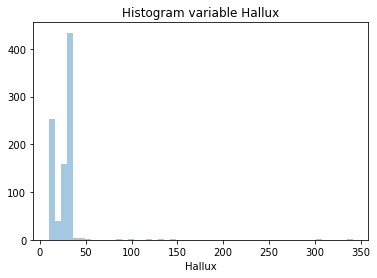

```python
sns.distplot( a=df1["Hallux"], hist=True, kde=False, rug=False )
plt.title("Histogram variable Hallux")
plt.show()
```

Se observa que hay unos outliers entre 100mm y 150mm y 2 valores por encima de 300mm. Estos dos valores se van a eliminar al parecer demasiado extremos y poder afectar a la calidad del modelo.

```python
df1.drop(df1[df1.Hallux > 300].index, inplace=True)
```

Verificamos que efectivamente se han eliminado estos datos.

```python
df1.info()
```

```
<class 'pandas.core.frame.DataFrame'>
Int64Index: 906 entries, 0 to 907
Data columns (total 19 columns):
 #   Column        Non-Null Count  Dtype
---  ------        --------------  -----
 0   Month         906 non-null    int32
 1   Day           906 non-null    int32
 2   Year          906 non-null    int32
 3   CaptureTime   906 non-null    category
 4   ReleaseTime   906 non-null    category
 5   BandNumber    906 non-null    category
 6   Species       906 non-null    category
 7   Age           906 non-null    category
 8   Sex           906 non-null    category
 9   Wing          905 non-null    float64
 10  Weight        896 non-null    float64
 11  Culmen        899 non-null    float64
 12  Hallux        900 non-null    float64
 13  Tail          906 non-null    int32
 14  StandardTail  571 non-null    float64
 15  Tarsus        75 non-null     float64
 16  WingPitFat    77 non-null     float64
 17  KeelFat       567 non-null    float64
 18  Crop          565 non-null    float64
dtypes: category(6), float64(9), int32(4)
memory usage: 144.8 KB
```

También vamos a mostrar la cuenta de los distintos valores de las variables categóricas para ver si podemos tener alguna categoría sobrerepresentada o infrarepresentada. Esto lo haremos con las variables **Species**, **Age** y **Sex**.

```python
print(df1.groupby(df1.Species).size())
print(df1.groupby(df1.Age).size())
print(df1.groupby(df1.Sex).size())
```

```
Species
CH     70
RT    575
SS    261
dtype: int64
Age
A    224
I    682
dtype: int64
Sex
     574
F    174
M    158
dtype: int64
```

Observamos que respecto a la variable **Sex** más de la mitad de las observaciones no están categorizadas, por lo tanto cualquier conclusión al respecto de esta variable habrá que vigilarla, no obstante las que se han categorizado parecen tener una proporción apropiada.

La variable **Age** tiene un sesgo con los ejemplares inmaduros que representan cerca del 75% de las muestras.

Finalmente, la variable que más nos va a afectar en el objetivo de esta práctica es la de **Species** en la cual encontramos una sobrerepresentación del halcón Red-tailed y una infrarepresentación del halcón Cooper correspondiendo al 63% y al 8% respectivamente.

## Aplicación del modelo no supervisado K-means

### Datos de entrada

Después de haber analizado las distintas variables nos encontramos en disposición de aplicar un modelo no supervisado de agregación mediante k-means. Para ello lo primero que haremos será descartar las columnas que no corresponden a este estudio quedándonos exlcusivamente con **Species**, **Wing**, **Weight**, **Culmen** y **Hallux**. Además eliminaremos los valores nulos de estas columnas.

```python
df_study = df1[["Species", "Wing", "Weight", "Culmen", "Hallux"]].dropna()
df_study.info()
df_study.head()
```

```
<class 'pandas.core.frame.DataFrame'>
Int64Index: 889 entries, 0 to 907
Data columns (total 5 columns):
 #   Column   Non-Null Count  Dtype
---  ------   --------------  -----
 0   Species  889 non-null    category
 1   Wing     889 non-null    float64
 2   Weight   889 non-null    float64
 3   Culmen   889 non-null    float64
 4   Hallux   889 non-null    float64
dtypes: category(1), float64(4)
memory usage: 35.7 KB
```

|  | Species | Wing | Weight | Culmen | Hallux |
| --- | --- | --- | --- | --- | --- |
| 0 | RT | 385.0 | 920.0 | 25.7 | 30.1 |
| 2 | RT | 381.0 | 990.0 | 26.7 | 31.3 |
| 3 | CH | 265.0 | 470.0 | 18.7 | 23.5 |
| 4 | SS | 205.0 | 170.0 | 12.5 | 14.3 |
| 5 | RT | 412.0 | 1090.0 | 28.5 | 32.2 |

Nos quedamos con un total de 889 muestras de las 908 iniciales, con las que podremos aplicar k-means.

El objetivo de esta práctica es asignar clasificar correctamente los distintos tipos de halcones, es decir, obtener la columna **Species**, por ello inicialmente eliminaremos esta columna y no la usaremos hasta el final como método de evaluación externa.

```python
df_selection = df_study[["Wing", "Weight", "Culmen", "Hallux"]]
```

### Normalización de los datos

K-means se basa en calcular distancias entre las distintas observaciones, esto significa que observaciones con magnitudes distintas pueden generar que algunas variables tengan un peso superior a otras, por ello se decide normalizar las cuatro variables de estudio y así asegurarnos de que todas ellas tengan el mismo peso.

Para ello se ha decidido usar una normalización min-max para tener de esta forma todos los valores en la escala [0-1].

```python
df_kmeans = (df_selection-df_selection.min())/(df_selection.max()-df_selection.min())
df_kmeans.describe()
```

|  | Wing | Weight | Culmen | Hallux |
| --- | --- | --- | --- | --- |
| count | 889.000000 | 889.000000 | 889.000000 | 889.000000 |
| mean | 0.629013 | 0.362038 | 0.431150 | 0.121664 |
| std | 0.215244 | 0.234560 | 0.238352 | 0.081021 |
| min | 0.000000 | 0.000000 | 0.000000 | 0.000000 |
| 25% | 0.372177 | 0.065350 | 0.137255 | 0.041948 |
| 50% | 0.751581 | 0.463019 | 0.552288 | 0.149064 |
| 75% | 0.796748 | 0.539007 | 0.611111 | 0.164045 |
| max | 1.000000 | 1.000000 | 1.000000 | 1.000000 |

### Aplicación de k-means

Para aplicar k-means debemos seleccionar el número de clusters que tendremos. Dado que conocemos el resultado final, sabemos que hay 3 grupos distintos de halcones, pero vamos a tratar de obtener este valor sin tener el cuenta nuestro conocimiento adicional sobre el dataset.

Para obtener el número de clusters necesarios lo que haremos será aplicar k-means para diversos valores de k y nos quedaremos con el número de clusters que dé la mejor solución.

Para la aplicación de k-means se ha tomado como ejemplo el código de [1].

Primero de todo, almacenamos los datos de las 4 variables de estudio en la matriz X.

```python
X = np.array(df_kmeans[["Wing", "Weight", "Culmen", "Hallux"]])
X.shape
```

```
(889, 4)
```

Evaluamos k-means para un rango entre 2 y 10 clusters y evaluamos la calidad de cada modelo aplicando el método elbow.

Al aplicar kmeans, fijamos random_state=10 para asegurarnos de que los resultados sean consistentes.

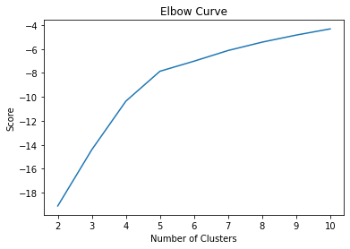

```python
#Applying k-means and evaluating its results for different k clusters.
Nc = list(range(2,11))
kmeans = [KMeans(n_clusters=i, random_state=10) for i in Nc]
score = [kmeans[i].fit(X).score(X) for i in range(len(kmeans))]

#Plotting the results
plt.plot(Nc,score)
plt.xlabel('Number of Clusters')
plt.ylabel('Score')
plt.title('Elbow Curve')
plt.show()
```

Para el método elbow encontramos que el punto de inflexión de la curva se encuentra para 4-5 clústers.

Evaluamos los distintos modelos con silhouette.

Para esto nos hemos basado en la explicación y los códigos de ejemplo de [2].

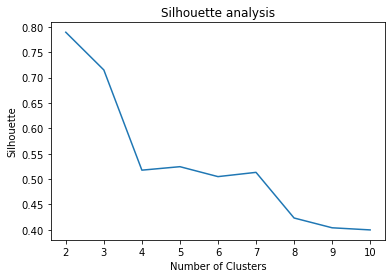

```python
#Compute the silhoutte average for each k number of clusters
cluster_labels = [kmeans[i].fit_predict(X) for i in range(len(kmeans))]
silhouette_avg = [silhouette_score(X, cluster_labels[i]) for i in range(len(kmeans))]
#Plotting the results
plt.plot(Nc,silhouette_avg)
plt.xlabel('Number of Clusters')
plt.ylabel('Silhouette')
plt.title('Silhouette analysis')
plt.show()
```

Según silhouette el mejor número de clústers para este dataset serían entre 2 y 3 clústers que es donde obtenemos los valores más elevados de silhouette.

Viendo todo esto y sabiendo que el número real de clústers es 3, tomaremos 3 clústers para continuar con el análisis de este ejercicio. De esta forma podremos evaluar como de bien se ha comportado k-means aplicando un modelo de evaluación externo.

Vamos a comparar visualmente los resultados obtenidos con k-means y los reales para hacernos una idea visual de como se ha comportado el modelo.

Análisis

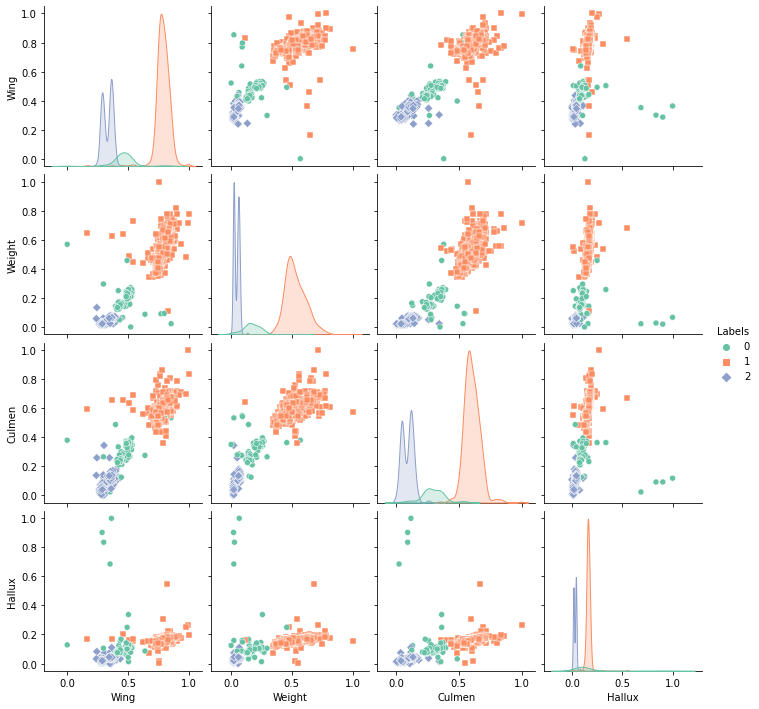

```python
#Applying k-means for 3 clusters:
kmeans_3 = KMeans(n_clusters=3, random_state=10)
cluster_labels = kmeans_3.fit_predict(X)
unique_labels = np.unique(cluster_labels)


#Labeling of the rows based on the kmeans
df_kmeans["Labels"] = kmeans_3.fit_predict(X)

#Plotting the different combinations of the four attributes
sns.pairplot(df_kmeans, kind="scatter", hue="Labels", markers=["o", "s", "D"], palette="Set2")
plt.show()
```

Basándonos en la representación del pairplot de las distintas variables parece que el modelo de kmeans ha discretizado bastante bien los 3 grupos pareciendo que hay una diferenciación clara en la mayoría de las combinaciones. Tras una inspección visual de los resultados se podría decir que el resultado es satisfactorio, no obstante vamos a buscar una evaluación externa ya que disponemos de la clasificación real de las distintas especies.

A continuación se muestran las 6 combinaciones de datos que provienen de combinar 2 a 2 las distintas variables comparadas con la clasificación real:

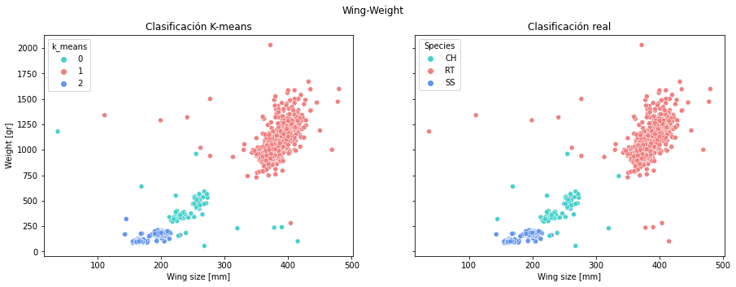

```python
df_final = df_study
df_final["k_means"] = df_kmeans["Labels"]


fig, axes = plt.subplots(1, 2, figsize=(15, 5), sharey=True)
fig.suptitle('Wing-Weight')

sns.scatterplot( x="Wing", y="Weight", data=df_final, hue='k_means', legend=True, ax=axes[0], palette = ["mediumturquoise", "lightcoral", "cornflowerblue"])
axes[0].set_title("Clasificación K-means")
axes[0].set_xlabel("Wing size [mm]")
axes[0].set_ylabel("Weight [gr]")

sns.scatterplot( x="Wing", y="Weight", data=df_final, hue='Species', legend=True, ax=axes[1], palette = ["mediumturquoise", "lightcoral", "cornflowerblue"])
axes[1].set_title("Clasificación real")
axes[1].set_xlabel("Wing size [mm]")
axes[1].set_ylabel("Weight [gr]")

plt.show()
```

Vemos como en esta primera comparación se observa que la predicción de k-means es muy cercana al clasificación real, solo observándose unos pequeños errores en algunos datos que se salen de la tendencia habitual de los datos de cada especie de halcón.

Dada esta buena predicción, nos encontraremos con unos resultados muy similares para los distintos pares de variables.

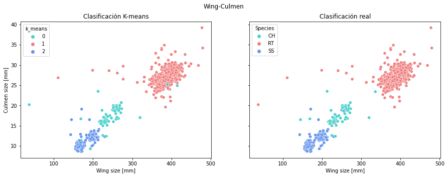

```python
fig, axes = plt.subplots(1, 2, figsize=(15, 5), sharey=True)
fig.suptitle('Wing-Culmen')

sns.scatterplot( x="Wing", y="Culmen", data=df_final, hue='k_means', legend=True, ax=axes[0], palette = ["mediumturquoise", "lightcoral", "cornflowerblue"])
axes[0].set_title("Clasificación K-means")
axes[0].set_xlabel("Wing size [mm]")
axes[0].set_ylabel("Culmen size [mm]")

sns.scatterplot( x="Wing", y="Culmen", data=df_final, hue='Species', legend=True, ax=axes[1], palette = ["mediumturquoise", "lightcoral", "cornflowerblue"])
axes[1].set_title("Clasificación real")
axes[1].set_xlabel("Wing size [mm]")
axes[1].set_ylabel("Culmen size [mm]")

plt.show()
```

Para la relación Wing-Culmen encontramos unos resultados muy similares, aquí se observa que algunas predicciones del halcón Cooper se han asignado incorrectamente a las otras dos especies, pero en general los resultados son muy buenos.

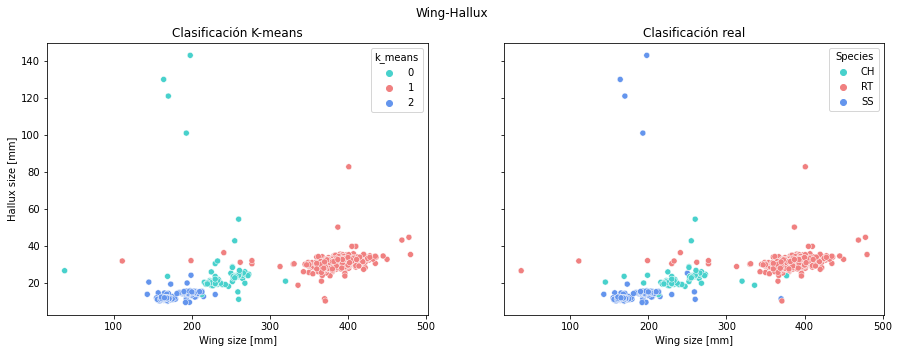

```python
fig, axes = plt.subplots(1, 2, figsize=(15, 5), sharey=True)
fig.suptitle('Wing-Hallux')

sns.scatterplot( x="Wing", y="Hallux", data=df_final, hue='k_means', legend=True, ax=axes[0], palette = ["mediumturquoise", "lightcoral", "cornflowerblue"])
axes[0].set_title("Clasificación K-means")
axes[0].set_xlabel("Wing size [mm]")
axes[0].set_ylabel("Hallux size [mm]")

sns.scatterplot( x="Wing", y="Hallux", data=df_final, hue='Species', legend=True, ax=axes[1], palette = ["mediumturquoise", "lightcoral", "cornflowerblue"])
axes[1].set_title("Clasificación real")
axes[1].set_xlabel("Wing size [mm]")
axes[1].set_ylabel("Hallux size [mm]")

plt.show()
```

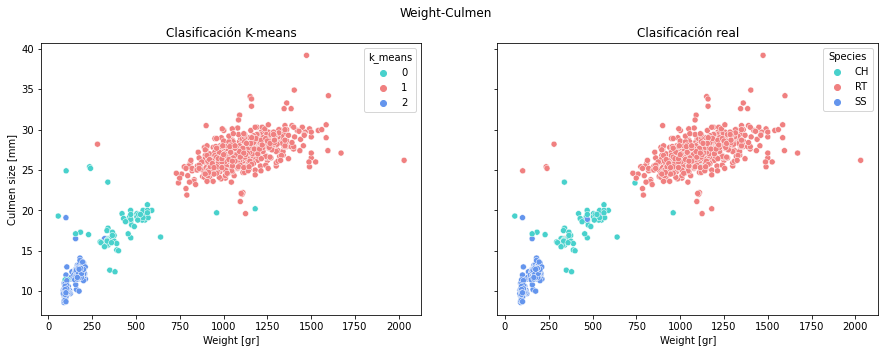

```python
fig, axes = plt.subplots(1, 2, figsize=(15, 5), sharey=True)
fig.suptitle('Weight-Culmen')

sns.scatterplot( x="Weight", y="Culmen", data=df_final, hue='k_means', legend=True, ax=axes[0], palette = ["mediumturquoise", "lightcoral", "cornflowerblue"])
axes[0].set_title("Clasificación K-means")
axes[0].set_xlabel("Weight [gr]")
axes[0].set_ylabel("Culmen size [mm]")

sns.scatterplot( x="Weight", y="Culmen", data=df_final, hue='Species', legend=True, ax=axes[1], palette = ["mediumturquoise", "lightcoral", "cornflowerblue"])
axes[1].set_title("Clasificación real")
axes[1].set_xlabel("Weight [gr]")
axes[1].set_ylabel("Culmen size [mm]")

plt.show()
```

Para la comparativa Weight-Culmen volvemos a tener 3 clústers muy bien definidos y el modelo clasifica muy bien las observaciones, hay algún error con el halcón Cooper y el Red-tailed, pero sobretodo con las observaciones que se salen de las medidas y pesos habituales.

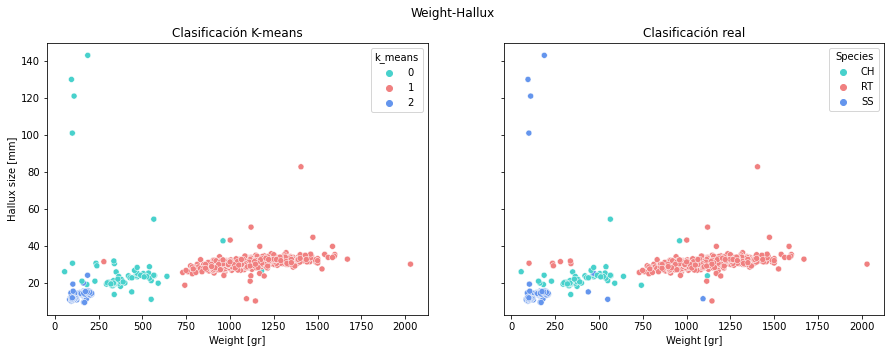

```python
fig, axes = plt.subplots(1, 2, figsize=(15, 5), sharey=True)
fig.suptitle('Weight-Hallux')

sns.scatterplot( x="Weight", y="Hallux", data=df_final, hue='k_means', legend=True, ax=axes[0], palette = ["mediumturquoise", "lightcoral", "cornflowerblue"])
axes[0].set_title("Clasificación K-means")
axes[0].set_xlabel("Weight [gr]")
axes[0].set_ylabel("Hallux size [mm]")

sns.scatterplot( x="Weight", y="Hallux", data=df_final, hue='Species', legend=True, ax=axes[1], palette = ["mediumturquoise", "lightcoral", "cornflowerblue"])
axes[1].set_title("Clasificación real")
axes[1].set_xlabel("Weight [gr]")
axes[1].set_ylabel("Hallux size [mm]")

plt.show()
```

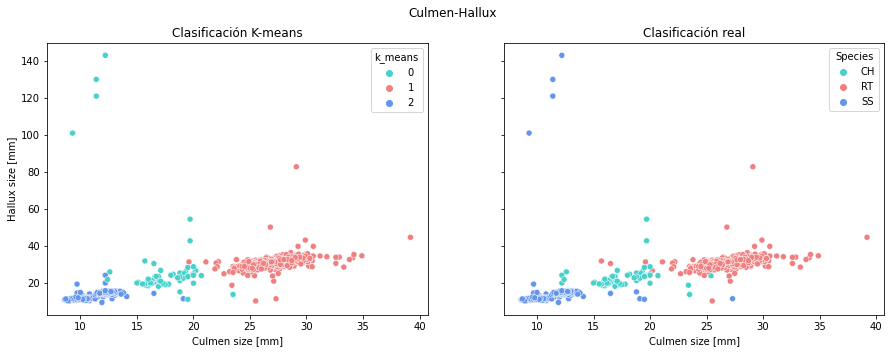

```python
fig, axes = plt.subplots(1, 2, figsize=(15, 5), sharey=True)
fig.suptitle('Culmen-Hallux')

sns.scatterplot( x="Culmen", y="Hallux", data=df_final, hue='k_means', legend=True, ax=axes[0], palette = ["mediumturquoise", "lightcoral", "cornflowerblue"])
axes[0].set_title("Clasificación K-means")
axes[0].set_xlabel("Culmen size [mm]")
axes[0].set_ylabel("Hallux size [mm]")

sns.scatterplot( x="Culmen", y="Hallux", data=df_final, hue='Species', legend=True, ax=axes[1], palette = ["mediumturquoise", "lightcoral", "cornflowerblue"])
axes[1].set_title("Clasificación real")
axes[1].set_xlabel("Culmen size [mm]")
axes[1].set_ylabel("Hallux size [mm]")

plt.show()
```

Finalmente, en la comparación Culmen-Hallux se aprecia una correlación entre el tamaño de la garra y de la pata del halcón como era previsible, además de encontrarse 3 grupos bastanteclaros que k-means localiza sin problemas.

### Evaluación externa del modelo

Dado que tenemos la clasificación exacta de las especies de halcones y la predicción del modelo podemos encontrar con que efectividad ha predecido k-means la especie de halcón.

```python
df_final["k_means_pred"] = ""
df_final.head()

df_final.loc[(df_final.k_means == 0), "k_means_pred"] = "CH"
df_final.loc[(df_final.k_means == 1), "k_means_pred"] = "RT"
df_final.loc[(df_final.k_means == 2), "k_means_pred"] = "SS"

correct_values = df_final[df_final.Species == df_final.k_means_pred]["Species"].count()
total_values = len(df_final)
prediction_rate_kmeans = (correct_values/total_values)

print("El modelo de k-means ha clasificado correctamente el {}% de las observaciones".format(prediction_rate_kmeans*100))
```

```
El modelo de k-means ha clasificado correctamente el 97.86276715410574% de las observaciones
```

## Conclusiones

Una vez realizada la clasificación por k-means usando 3 clústers se ha observado que estos clústers estaban bastante definidos en la mayoría de atributos, lo que ha facilitado la generación de un modelo que clasifica las distintas especies de halcón con bastante precisión.

Nos encontramos con algunas observaciones que se salían de los valores usuales de cada especie de halcón y era con esos con los que el modelo solía fallar como sería de esperar.

Finalmente se ha buscado que tasa de acierto tiene el modelo, consiguiendo un 97,9% de acierto, lo cual es una precisión muy elevada e indica que el modelo obtenido clasifica con gran exactitud estas especies de halcones con las variables de partida de este estudio.

# Ejercicio 2

## Introducción

Tras analizar los distintos datos con k-means en este apartado se proponer utilizar un modelo basado en densidad como sería DBSCAN u OPTICS para realizar el mismo ejercicio de clasificación realizado en el apartado anterior y así poder comparar los resultados de ambos modelos.

Primero se estudiará la precisión de DBSCAN y posteriormente se aplicará OPTICS, con esos resultados podremos comparar la eficiencia de ambos algoritmos.

Guardamos el dataframe a emplear en este apartado:

```python
df_density = df_kmeans
df_density.head()
```

|  | Wing | Weight | Culmen | Hallux | Labels |
| --- | --- | --- | --- | --- | --- |
| 0 | 0.785456 | 0.437690 | 0.558824 | 0.154307 | 1 |
| 2 | 0.776423 | 0.473151 | 0.591503 | 0.163296 | 1 |
| 3 | 0.514453 | 0.209726 | 0.330065 | 0.104869 | 0 |
| 4 | 0.378952 | 0.057751 | 0.127451 | 0.035955 | 2 |
| 5 | 0.846432 | 0.523810 | 0.650327 | 0.170037 | 1 |

## DBSCAN y OPTICS

### Introducción y generación de los primeros modelos con DBSCAN

DBSCAN es un algoritmo basado en densidad el cual a partir de una distancia (epsilon) y un número de puntos mínimos (minPts) para considerar un clúster, nos generará una clasificación de las muestras de nuestro dataset. Su funcionamiento corresponde en buscar un punto núcleo que a una distancia epsilon tenga por lo menos minPts-1 (ya que él también formará parte del clúster). Todos los puntos que queden conectados mediante este método formarán un clúster. Es decir, DBSCAN agrupará todos los puntos que se encuentren cercanos siempre y cuando haya una cantidad de puntos los suficientemente alta (densa).

Este algoritmo es muy bueno identificando clústers de diferentes geometrías y que identifique correctamente valores extremos, además no requerirá que le precisemos un número de clústers ya que lo determinará él solo. No obstante, tenemos que aportarle un valor de epsilon y de minPts el cual puede ser difícil de acertar incialmente y suele requerir de experiencia y conocimiento del dataset para poder proporcionar unos valores óptimos.

En este ejercicio generaremos un modelo inicial de DBSCAN para poder estimar minPts y epsilon, a continuación se generará una optimización de estos valores basandonos en una evaluación del modelo con Silhouette. Después procederemos a optimizar este valor con OPTICS consiguiendo de esta forma justificar la utilización de este algoritmo en la búsqueda del mejor valor de epsilon para determinar el número de clústers deseados y reduciendo el ruído al mínimo. Finalmente haremos una evaluación interna y externa del modelo para determinar su calidad.

Inicialmente vamos a importar las librerías necesarias:

```python
from sklearn.cluster import DBSCAN, OPTICS, cluster_optics_dbscan
from sklearn import metrics

#For combinatories in the plotting:
import itertools
```

A continuación, cogemos el conjunto de datos "X" que serán los 4 atributos con los que trabajamos en este proyecto **Wing**, **Weight**, **Culmen** y **Hallux** y podemos generar el modelo de clustering DBSCAN [3]:

```
Silhouette score for epsilon: 0.1 and minPts: 5 is: 0.7317920760507809
```

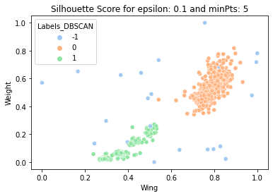

```python
#Array with the data for fitting the model.
X = np.array(df_density[["Wing", "Weight", "Culmen", "Hallux"]])

#As this code is going to be used multiple times a function of it is made.
def fun_DBSCAN(epsilon,minPts, sil = False, plot = False):

    #Training of the model
    clustering = DBSCAN(eps=epsilon, min_samples=minPts).fit(X)
    cluster_labels = clustering.fit_predict(X)
    df_density["Labels_DBSCAN"] = cluster_labels

    #Evaluation of the model
    silhouette_DBSCAN = silhouette_score(X, cluster_labels)
    if sil == True:
        print("Silhouette score for epsilon: {} and minPts: {} is: {}".format(epsilon, minPts, silhouette_DBSCAN))

    #Plot the results
    if plot == True:
        sns.scatterplot( x="Wing", y="Weight", data=df_density, hue='Labels_DBSCAN', legend=True, palette = "pastel")
        plt.title("Silhouette Score for epsilon: {} and minPts: {}".format(epsilon, minPts))
        plt.show()
    return cluster_labels

fun_DBSCAN(0.1, 5, sil = True, plot=True)
plt.show()
```

Una primera evaluación del modelo se ha realizado con epsilon=0.1 y minPts=5, con lo que obtenemos el resultado mostrado anteriormente. En este primer modelo se observa que se han generado dos clústers uno en la zona superior derecha y otro en la zona central inferior. Además encontramos diversas muestras que, al encontrarse en zonas con una baja densidad de muestras, no se han asignado a ninguno de los clústers.

Se ha realizado una evaluación del modelo obtenido mediante silhouette y se obtiene un resultado de 0,732 el cual es bastante elevado, cosa que contrasta con nuestro conocimiento del resultado correcto, ya que tenemos un clúster menos de los que existen en realidad y hay valores sin asignar. Este contraste se debe principalmente a que Silhouette evalúa como de agrupados están los puntos de un clúster y como de lejos de los otros clústers se encuentran, por ello no será capaz de identificar que el clúster inferior debería separarse en otros dos.

### Optimización de epsilon y minPts

A continuación se va a tratar de buscar un valor óptimo de epsilon y minPts, utilizando Silhouette como medida de la calidad del modelo obtenido. Para ello se van a proponer un seguido de valores de epsilon y de minPts y se analizarán los resultados.

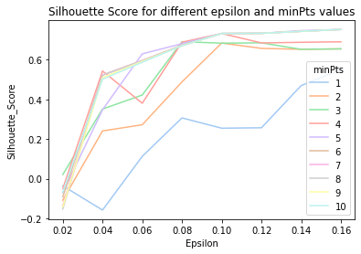

```python
# The values for epsilon and minPts are defined in two lists to iterate aftewards.
epsilons = [x/100 for x in list(range(2, 18, 2))]
minPts = list(range(1,11))
sil_list = []

# Loop finding for each combination of epsilon and minPts its average Silhouette score
# and storing it in sil_list.
for epsilon in epsilons:
    for p in minPts:
        values_list = [epsilon]
        values_list.append(p)
        clustering = DBSCAN(eps=epsilon, min_samples=p).fit(X)
        cluster_labels = clustering.fit_predict(X)
        values_list.append(silhouette_score(X, cluster_labels))
        sil_list.append(values_list)

# Saving the data in a dataframe to work easily with it.
df_sil = pd.DataFrame(sil_list, columns = ['Epsilon', 'minPts', 'Silhouette_Score'])

# Plotting the data.
sns.lineplot(data=df_sil, x="Epsilon", y="Silhouette_Score", hue="minPts", palette="pastel")
plt.title("Silhouette Score for different epsilon and minPts values")
plt.show()
```

De la evaluación con Silhouette de la calidad del modelo se obtienen diversas conclusiones muy interesantes. Vemos que por lo general al aumentar epsilon Silhouette también lo hace, ya que se amplia la distancia y más elementos se pueden incluir en el clúster, reduciendo así el número de datos no clasificados. En momentos puntuales en los que disminuye, se deben a que a partir de esa epsilon el modelo genera un clúster para datos que se encontraban hasta ahora sin clasificar, reduciendo así la eficiencia del modelo.

En cuanto minPts, un mayor número de puntos para considerar un clúster genera unos resultados más satisfactorios, especialmente con distáncias pequeñas, observándose como con un número elevados de puntos la función converge para epsilon=0.04 o 0.06, mientrás que para un menor número de puntos la convergencia se alcanza entre 0.08 y 0.1.

Para escoger el valor definitivo se ha optado por acompañar la decisión de una revisión gráfica de los resultados. Se decide, optar por unos valores entorno a epsilon 0.08-0.1 que es donde parece que empiezan a converger los resultados y un número mínimo de puntos de unos 4 y 6 puntos, para exigir unos clústers densos, pero sin que excluya zonas muy grandes de baja densidad.

```
Silhouette score for epsilon: 0.08 and minPts: 4 is: 0.68791891258119
Silhouette score for epsilon: 0.08 and minPts: 6 is: 0.6732165048905984
Silhouette score for epsilon: 0.1 and minPts: 4 is: 0.7317920760507809
Silhouette score for epsilon: 0.1 and minPts: 6 is: 0.7317920760507809
```

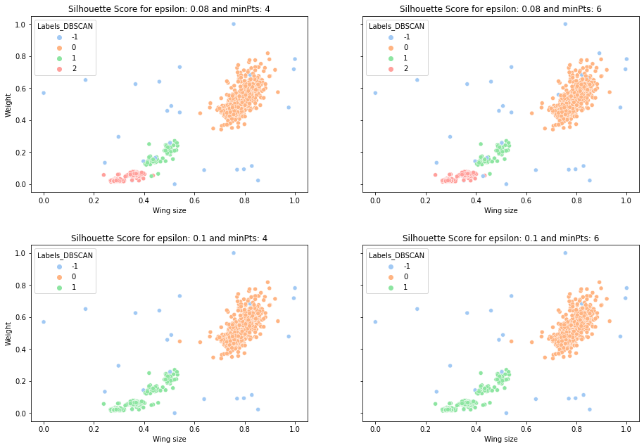

```python
#Trying with epsilon = 0.08
fig, axes = plt.subplots(2, 2, figsize=(15, 10), sharey=True)

#Plotting different combinations:
i = 0
for epsilon in [0.08, 0.1]:
    j = 0
    for minPts in [4,6]:
        df_density["Labels_DBSCAN"] = fun_DBSCAN(epsilon, minPts, sil = True)
        sns.scatterplot( x="Wing", y="Weight", data=df_density, hue="Labels_DBSCAN", legend=True, palette = "pastel", ax = axes[i,j])
        axes[i,j].set_title("Silhouette Score for epsilon: {} and minPts: {}".format(epsilon, minPts))
        axes[i,j].set_xlabel("Wing size")
        axes[i,j].set_ylabel("Weight")
        j += 1
    i+=1

plt.subplots_adjust(left=0.1, bottom=0.1, right=0.9, top=0.9, wspace=0.2, hspace=0.3)
```

Como se puede ver en estos gráficos al emplear un epsilon de 0.1 las dos categorías inferiores se agrupan formando un único clúster, esto es debido a que las características de estos dos tipos de halcón son muy similares y DBSCAN al tratarse de un algoritmo basado en densidad, si somos poco estrictos con el agrupamiento se agrupan estos dos clústers.

Con epsilon=0.08 se obtiene una clasificación que, al conocer previamente la distribución de los datos, se acerca más a la realidad, además de observarse de forma gráfica como el clúster de la zona inferior en función de la precisión se discretizará en uno, dos o 3 clústers.

Con el número de puntos no se obtiene una diferencia sustancial, obteniendose que para epsilon 0.1 no hay diferencia con el número de puntos y con 0.08 la diferencia es muy escasa, siendo mejor para minPts=4 al ser menos exigente.

### Determinación de epsilon usando OPTICS

OPTICS es un algoritmo que generaliza DBSCAN, requiriendo tan solo una variable de entrada, el número mínimo de puntos para considerar un clúster. A partir de este dato, genera una reachibility-distance que será la máxima entre epsilon (distancia para contener el número mínimo de puntos) o la distancia al núcleo. De esta forma asignaremos una reachibility-distance a todos los puntos obteniendo valores bajos para las zonas más densas y valores altos para los outliers. Se podrá ajustar la distancia para la cual se considera un valor un outlier, ajustando así el número de clústers.

Con el valor de OPTICS y el gráfico de reachability podemos determinar el valor de epsilon con el que obtendremos cada número de clústers para un número mínimo de puntos.

Siguiendo el código ejemplo y la teoría de [4] generamos el primer modelo de OPTICS con un número de puntos inicial de 4. Y obtenemos la ordenación de las muestras por su reachability distance

```python
clustering = OPTICS(min_samples=4).fit(X)
order = clustering.ordering_
print(order)
```

[output not shown]

[output cut: 35 more lines]

En este vector encontramos ordenados todos los puntos del dataset respecto al punto núcleo.

A continuación se mostrará el reachability plot donde podremos observar la alcanzabilidad de los distintos puntos. Y a partir de esta determinar cuantos clúster se generarán con DBSCAN.

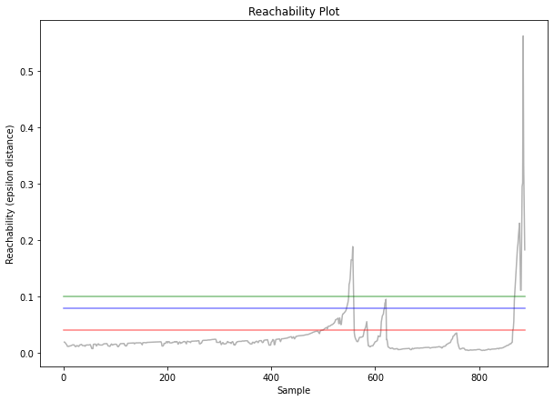

```python
def fun_OPTICS(samples, plot = False):
    # Training the OPTIC's model.
    clustering = OPTICS(min_samples=samples).fit(X)

    # Finding data of the model to plot the reachability plot.
    space = np.arange(len(X))
    reachability = clustering.reachability_[clustering.ordering_]
    labels = clustering.labels_

    if plot == True:
        plt.figure(figsize=(10, 7))
        plt.plot(space[labels == -1], reachability[labels == -1],"k", alpha=0.3)
        plt.xlabel("Sample")
        plt.ylabel("Reachability (epsilon distance)")
        plt.title("Reachability Plot")

fun_OPTICS(4, plot=True)
space = np.arange(len(X))
plt.plot(space, np.full_like(space, 0.04, dtype=float), "r", alpha=0.5)
plt.plot(space, np.full_like(space, 0.08, dtype=float), "b", alpha=0.5)
plt.plot(space, np.full_like(space, 0.1, dtype=float), "g", alpha=0.5)
plt.show()
```

Con el reachability plot observamos las zonas valle y los picos, estas zonas valle representan los distintos clústers. Con este gráfico podemos determinar para los distintos valores de epsilon cuantos clústers se formarán, de esta forma podemos comprobar que, como habíamos visto en el apartado anterior para minPts=4 con epsilon=0.1 se formaban dos clústers, y con 0.08 se formaban 3 clústers. Esto queda definido en el reachability plot con las líneas que hemos definido en color verde (epsilon=0,1), en la cual se observan dos valles bajo esta línea y en azul (epsilon 0,08) la cual delimita 3 valles. Esto coincide con los resultados del apartado anterior.

Por otro lado se observa con la línea roja (epsilon=0.04) se generan 4 zonas valle, generando así 4 clústers. A continuación se aplica DBSCAN con epsilon=0.04 para mostrar como efectivamente aparecerán estos 4 clústers.

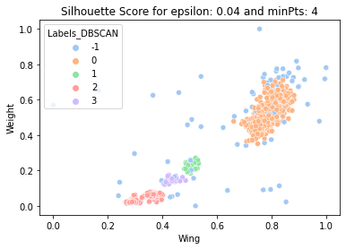

```python
fun_DBSCAN(0.04, 4, plot = True)
plt.show()
```

Efectivamente, tal y como se esperaba aparecen los 4 clústers comentados previamente.

Con OPTICS podemos deducir que con un mínimo de 4 puntos para un rango de epsilon entre 0.05 y 0.095 obtendremos 3 clústers.

A continuación evaluamos OPTICS para minPts=6 como habíamos hecho en el apartado anterior.

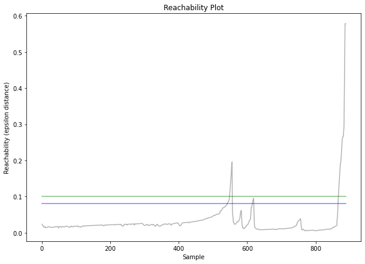

```python
fun_OPTICS(6, plot=True)
plt.plot(space, np.full_like(space, 0.08, dtype=float), "b", alpha=0.5)
plt.plot(space, np.full_like(space, 0.1, dtype=float), "g", alpha=0.5)
```

Se observa que el reachability plot prácticamente no varía con un mínimo de puntos de 4 y 6, lo que significa que los clústers identificados son muy densos y se puede exigir un valor alto de puntos mínimos o un valor bajo de epsilon.

Con el análisis con OPTICS se observa como se reduce la complejidad a la hora de determinar epsilon respecto a la optimización del apartado anterior.

### Evaluación del modelo de DBSCAN (Validación interna)

Se decide escoger como valor óptimo epsilon=0.09 y minPts = 4. Primero de todo obtenemos el modelo de DBSCAN para estos valores.

Con esto añadimos los resultados de DBSCAN al dataframe definitivo y procedemos a su análisis.

```python
df_final["DBSCAN"] = fun_DBSCAN(0.09, 4)

df_final.head()
```

|  | Species | Wing | Weight | Culmen | Hallux | k_means | k_means_pred | DBSCAN |
| --- | --- | --- | --- | --- | --- | --- | --- | --- |
| 0 | RT | 385.0 | 920.0 | 25.7 | 30.1 | 1 | RT | 0 |
| 2 | RT | 381.0 | 990.0 | 26.7 | 31.3 | 1 | RT | 0 |
| 3 | CH | 265.0 | 470.0 | 18.7 | 23.5 | 0 | CH | 1 |
| 4 | SS | 205.0 | 170.0 | 12.5 | 14.3 | 2 | SS | 2 |
| 5 | RT | 412.0 | 1090.0 | 28.5 | 32.2 | 1 | RT | 0 |

Para estos valores óptimos se realiza una comparación de las distintas variables dos a dos comparando los resultados del modelo con los reales.

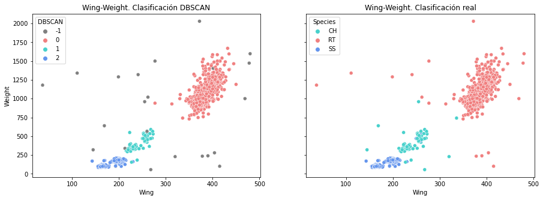

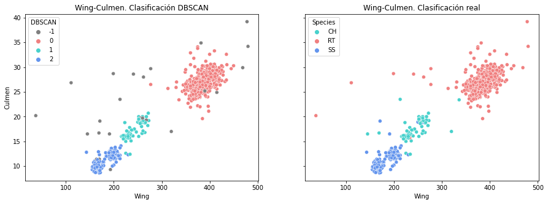

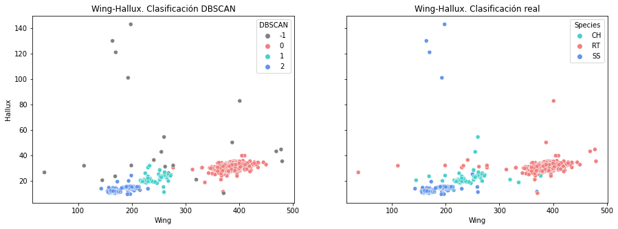

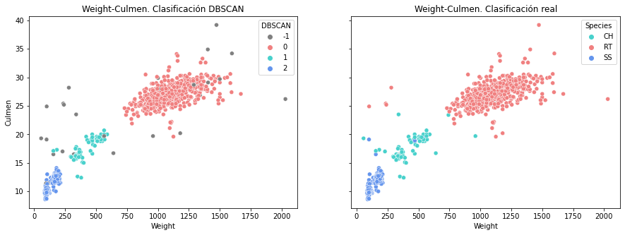

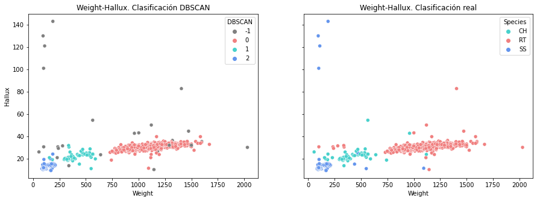

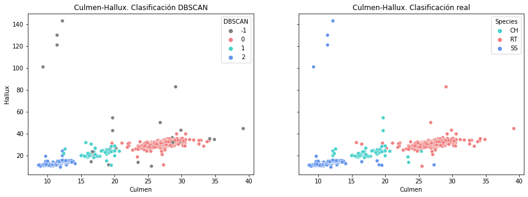

```python
atributes_list = ["Wing", "Weight", "Culmen", "Hallux"]
subsets_list = []
for subset in itertools.combinations(atributes_list, 2):
    subsets_list.append(list(subset))

for atributes in subsets_list:
    fig, axes = plt.subplots(1, 2, figsize=(15, 5), sharey=True)

    sns.scatterplot( x=atributes[0], y=atributes[1], data=df_final, hue='DBSCAN', legend=True, ax=axes[0], palette = ["grey", "lightcoral", "mediumturquoise", "cornflowerblue"])
    axes[0].set_title("{}-{}. Clasificación DBSCAN".format(atributes[0], atributes[1]))

    sns.scatterplot( x=atributes[0], y=atributes[1], data=df_final, hue='Species', legend=True, ax=axes[1], palette = ["mediumturquoise", "lightcoral", "cornflowerblue"])
    axes[1].set_title("{}-{}. Clasificación real".format(atributes[0], atributes[1]))
    plt.show()
```

Tras comparar los resultados del modelo de clasificación de DBSCAN con la clasificación real se deduce que los resultados obtenidos son satisfactorios, obteniendo un modelo de clasificación que ha ordenado el dataset original con un porcentaje de acierto muy elevado tras una inspección visual inicial.

Aunque parece que en la mayoría de combinaciones aparecen valores fuera de los 3 clústers principales correspondientes a las distintas especies de halcones, estos raramente han sido clasificados dentro de uno de los clústers. Esto se debe a que DBSCAN es un modelo basado en densidad y, por tanto, no clasificará los valores que no sean similares al resto de su clúster.

La comparación Wing-Weight parece estar correlacionada, y tiene sentido que el tamaño de las alas sea mayor en ejemplares de mayor peso ya que su tamaño general será más grande. Con estas variables se observa un seguido de outliers que no han sido clasificados probablemente porque con el resto de variables tampoco habrán tenido una gran correlación. Para el halcón Cooper se observan algunos puntos que no han sido clasificados en el clúster principal, probablemente por valores inusuales en **Culmen** o **Hallux**.

En la comparación Wing-Culmen parece que también encontramos una cierta correlación de las variables al encontrarse estas prácticament en una línes recta. Esto tiene sentido ya que el tamaño del ala de un halcón estará relacionado con el tamaño de su garra. En cuanto a los resultados del modelo de clasificación sorprende observar que diversos puntos no clasificados se encuentran dentro de los clústers, esto puede suceder debido a que al haber una dispersión baja de los puntos fuera de la línea principal, en la combinación de estas variables no se observa la distancia real que tienen esos datos al resto de los resultados, la cual hace que no se puedan asignar estos valores a los clústers que aquí parecen similares.

En la comparación Wing-Hallux también se observa la correlación previamente mencionada. Por otro lado aquí si que se observa una mayor dispersión de los datos haciendo que estos no se hayan podido asignar a ninguno de los clústers obtenidos.

En la comparación Weight-Culmen encontramos bastante dispersión en las observaciones de menor peso generando bastantes puntos no clasificados en esta zona. Esto puede ser debido a que haya machos y hembras en el muestreo los cuales habitualmente suelen diferir en tamaño. Esta separación en dos grupos de pesos diferentes se observa en especial con el halcón Cooper, en el que se ven dos clústers.

En la comparación Weight-Hallux también se observa una serie de observaciones con una mayor dispersión y otras que se pueden considerar como outliers, las cuales no han sido clasificadas. El haclón Sharp-Shinned muestra una gran dispersión en algunas muestras tanto en peso como en tamaño de la pata, mientras que los outliers en tamaño de garra no se han clasificado, los del peso se han clasificado incorrectamente.

Finalmente en la comparación Culmen-Hallux se sigue lo comentado previamente encontrando una correlación entre ambas variables y habiendo un seguido de muestras que se alejan de los clústers identificados y que no han podido ser clasificadas.

Como conclusión final, se observa que al tratarse DBSCAN de un algoritmo de clasificación basado en densidad, como era de esperar las observaciones que se alejan más de los clústers principales no han podido ser clasificadas.

### Evaluación del modelo de DBSCAN (Validación externa)

Finalmente se realiza una evaluación externa del modelo al conocer las distintas especies de halcones.

```python
df_final["DBSCAN_pred"] = ""

df_final.loc[(df_final.DBSCAN == -1), "DBSCAN_pred"] = "UN"
df_final.loc[(df_final.DBSCAN == 0), "DBSCAN_pred"] = "RT"
df_final.loc[(df_final.DBSCAN == 1), "DBSCAN_pred"] = "CH"
df_final.loc[(df_final.DBSCAN == 2), "DBSCAN_pred"] = "SS"

correct_values = df_final[df_final.Species == df_final.DBSCAN_pred]["Species"].count()
unclasified_values = df_final[df_final.DBSCAN == -1]["Species"].count()
total_values = len(df_final)
prediction_rate_dbscan = (correct_values/(total_values-unclasified_values))
unclasified_rate = (unclasified_values/(total_values))
total_rate_dbscan = (1-unclasified_rate)*prediction_rate_dbscan

print("El modelo de DBSCAN ha clasificado un {}% de las observaciones, \nde las cuales el {}% lo ha hecho correctamente.".format((1-unclasified_rate)*100, prediction_rate_dbscan*100))
print("Sobre el total de muestras se clasifican correctamente el {}% de las observaciones".format(total_rate_dbscan))
```

```
El modelo de DBSCAN ha clasificado un 96.51293588301463% de las observaciones,
de las cuales el 98.83449883449883% lo ha hecho correctamente.
Sobre el total de muestras se clasifican correctamente el 0.953880764904387% de las observaciones
```

Con esta evaluación deducimos que el modelo de DBSCAN funciona con una alta precisión al haber clasificado el 96,5% de las muestras y haberlo hecho correctamente con el 98,8% de éstas.

### Conclusiones finales

Con DBSCAN hemos conseguido generar un modelo de clasificación que funciona con una alta calidad clasificando las muestras del dataset original. No obstante, este algoritmo deja algunas muestras sin clasificar al estar en zonas poco densas. Al tratarse de un modelo de densidad hay dos factores a tener en cuenta, el primero es que las distintas categorias deben tener una densidad constante ya que de no ser así, estas diferencias de densidad podría generar que se generen distintos clústers para un grupo o un clúster que englobe varios grupos. Por otro lado, el tamaño del dataset determinará el número de puntos mínimos a tomar, ya que un dataset con 1000000 de datos tendrá una densidad muy superior a uno con 1000 muestras y, por tanto, para una misma distancia epsilon tendremos que ser mucho más exigentes con el numero de puntos mínimos.

En cuanto a la calidad del modelo, finalmente se ha conseguido un modelo que ofrece una precisión bastante elevada con el cual se clasifican el 96,5% de los datos y de estos el 98,8% lo hacen correctamente, lo que nos da un total de 95,4% de muestras clasificadas correctamente. Esta precisión es muy elevada y se puede considerar que el modelo funciona correctamente.

# Ejercicio 3

## Introducción

Previamente se ha realizado un ejercicio de clasificación de un dataset sobre halcones en el que teníamos 3 especies distintas y a partir de 4 atributos de estos datos queríamos evaluar la calidad de lo algoritmos de clasificación k-means y DBSCAN.

Se ha realizado el ejercicio con ambos algoritmos y se han obtenido unas conclusiones sobre su calidad tras una evaluación interna y una externa. A continuación, se procede a comparar los resultados obtenidos con los distintos algoritmos empleados, comparando así el funcionamiento y los resultados de ambos algoritmos. Después se procederá a mostrar las ventajas y desventajas de cada algoritmo. Finalmente, se darán unas conclusiones finales a este ejercicio.

## Comparación k-means y DBSCAN

K-means es un algoritmo de clasificación que partiendo de un número determinado de semillas generará unos clústers por cercanía mientras que DBSCAN es un algoritmo basado en densidad por lo que generará clústers en zonas de densidad constante. Esta diferencia hace que los resultados sean distintos.

Por un lado con k-means es el analista quien determina el número de clústers, asignándose todas las observaciones a uno de estos clústers iniciales, obteniéndose unos resultados de mayor o menor calidad.

Por otro lado con DBSCAN partimos de indicar una densidad a partir de una distancia (epsilon) y un número de puntos en esta distancia (minPts) y a partir de estos datos generaremos clústers. Por tanto, este modelo genera los clústers basándose en diferencias de densidad y es este criterio el que tenemos que ajustar, lo que requerirá un buen conocimiento de los datos para escoger unos valores apropiados de epsilon y minPts. OPTICS nos permite determinar la alcanzabilidad (reachability) de cada punto del dataset, generando un reachability plot, con el que podremos determinar de forma visual como de densos son los distintos clústers del dataset y que tolerancia de epsilon debemos aceptar para que se forme un número determinados de clúster. Este algoritmo nos permitirá para un número determinado de minPts determinar el valor de epsilon para obtener unos resultados apropiados.

A continuación se van a comparar los resultados obtenidos con el modelo final de k-means y el de DBSCAN teniendo en cuenta que para ambos modelos se ha buscado obtener 3 clústers distintos con la mejor calidad posible. Se muestran los resultados reales y de los dos modelos para cada combinación de atributos dos a dos. También imprimiremos por pantalla la calidad de cada algoritmo obtenida con la evaluación externa.

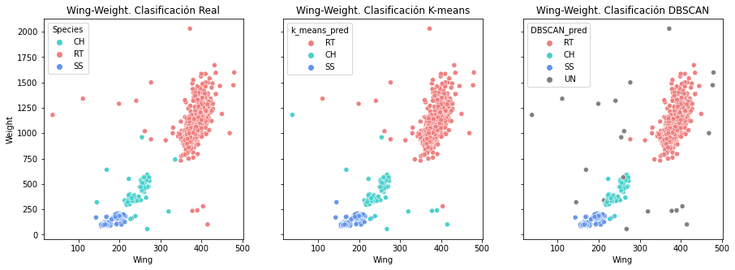

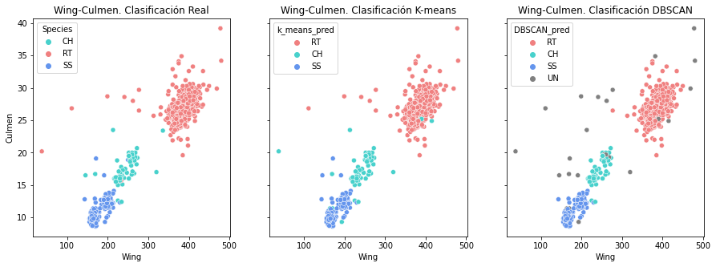

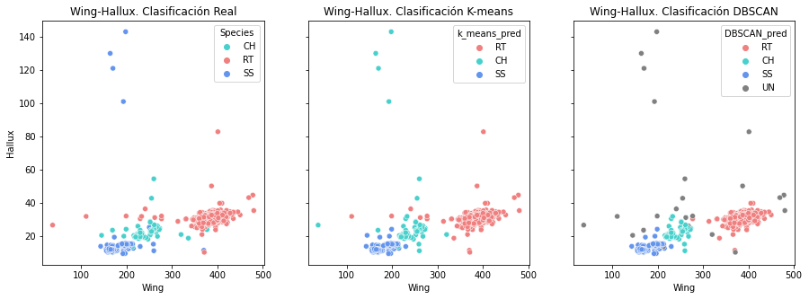

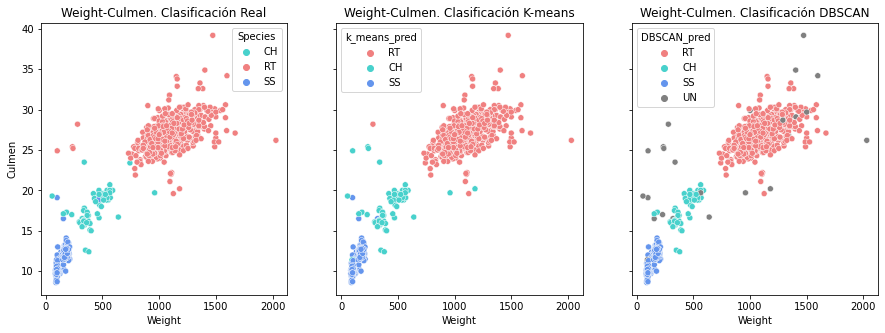

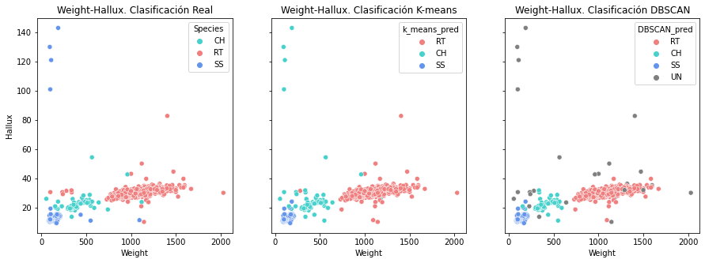

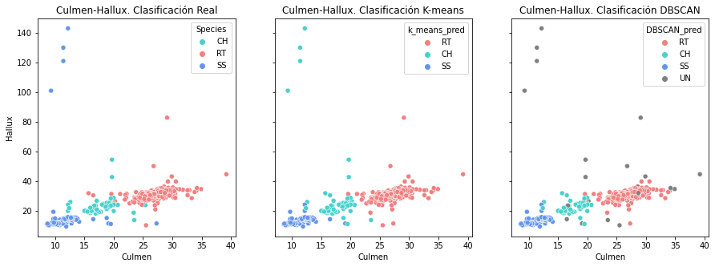

```
El modelo de k-means ha clasificado correctamente el 97.86276715410574% de las observaciones
El modelo de DBSCAN ha clasificado un 96.51293588301463% de las observaciones,
de las cuales el 98.83449883449883% lo ha hecho correctamente.
Sobre el total de muestras se clasifican correctamente el 95.3880764904387% de las observaciones
```

```python
for atributes in subsets_list:
    fig, axes = plt.subplots(1, 3, figsize=(15, 5), sharey=True)

    sns.scatterplot( x=atributes[0], y=atributes[1], data=df_final, hue='Species', legend=True, ax=axes[0], palette = ["mediumturquoise", "lightcoral", "cornflowerblue"])
    axes[0].set_title("{}-{}. Clasificación Real".format(atributes[0], atributes[1]))

    sns.scatterplot( x=atributes[0], y=atributes[1], data=df_final, hue='k_means_pred', legend=True, ax=axes[1], palette = ["lightcoral", "mediumturquoise", "cornflowerblue"])
    axes[1].set_title("{}-{}. Clasificación K-means".format(atributes[0], atributes[1]))

    sns.scatterplot( x=atributes[0], y=atributes[1], data=df_final, hue='DBSCAN_pred', legend=True, ax=axes[2], palette = ["lightcoral", "mediumturquoise", "cornflowerblue", "grey"])
    axes[2].set_title("{}-{}. Clasificación DBSCAN".format(atributes[0], atributes[1]))
    plt.show()


print("El modelo de k-means ha clasificado correctamente el {}% de las observaciones".format(prediction_rate_kmeans*100))
print("El modelo de DBSCAN ha clasificado un {}% de las observaciones, \nde las cuales el {}% lo ha hecho correctamente.".format((1-unclasified_rate)*100, prediction_rate_dbscan*100))
print("Sobre el total de muestras se clasifican correctamente el {}% de las observaciones".format(total_rate_dbscan*100))
```

A partir de estos gráficos se pueden sacar distintas conclusiones.

La primera, y más evidente, es que el modelo de k-means clasifica correctamente un mayor porcentaje de muestras, obteniendo un resultado un 2,5% más elevado, por lo tanto se puede afirmar que para este dataset, k-means proporciona unos resultados de mayor calidad. No obstante ambos modelos proporcionan una calidad muy elevada.

Otra de las diferencias claras entre ambos modelos es como se tratan los outliers, con DBSCAN encontramos que estos se dejan sin clasificar, al encontrarse en una zona de baja densidad, mientras que k-means los asigna al clúster con el centroide a la menor distancia, es decir, al clúster al que son más similares. Este comportamiento de k-means puede ser bueno porque clasifica todos los datos y, es probable que haga este ejercicio correctamente ya que lo asigna al clúster más similar, pero también puede disminuir la precisión de cada clúster como puede pasar con el halcón Sharp-Shinned el cual tiene unos valores para el tamaño de la pata bastante dispares en algunas muestras, k-means lo clasifica de forma incorrecta al halcón Cooper, con lo que modifica el centroide de este (aunque sean pocas muestras al estar tan alejadas, lo desplazaran) y reduce de esta forma la calidad de este clúster.

Tras observar estos resultados la gestión de los outliers se aprecia que k-means normalmente clasificaba correctamente los outliers del halcón Red-Tailed, mientras que los del halcón Cooper y Shapr-Shinned los confundia. Esto es probable que se deba a que el clúster de Red-Tailed está más diferenciado de los otros dos y es más sencillo diferenciarlo mientras que los otros dos, como se ha visto con DBSCAN, son más similares y era más difícil diferenciarlos, lo que hace que cuando se gestiona un outlier sea mucho más dificil de clasificarlo en una de las dos categorías.

## Ventajas y desventajas de cada algoritmo

Tras haber estudiado estos dos algoritmos se detecta que cada uno de ellos tiene unas ventajas e inconvenientes que habrá que tener en cuenta a la hora de escoger uno de los algoritmos.

Ventajas k-means

- k-means exclusivamente requiere escoger el número de clústers deseados. Y nos da la posibilidad de escoger las semillas iniciales para garantizar la reproducibilidad del código.
- Es un algoritmo sencillo de aplicar y proporciona unos resultados facilmente comprensibles. Con un análisis de los distintos valores de k se puede determinar el valor de clústers óptimo.
- Converge facilmente, con un estudio de los diferentes valores de k, encontraremos un valor para el que el modelo converge.

Desventajas k-means

- Entre las desventajas de k-means encontramos tener que escoger el valor de los clústers deseados, el cual se ha visto que a pesar de un análisis con Silhouette y con el método *elbow* ha sido difícil determinar un número apropiado de clústers y es probable que con diversos datasets sin un conocimiento previo de estos se pueda escoger un número de clústers erroneo.
- Como se ha mencionado anteriormente, la gestión de los outliers de k-means puede perjudicar la calidad final del modelo, ya que k-means buscará el centroide de cada clúster y, a partir de este, determinará que puntos pertenecen al clúster y cuales no. Esto hace que al asignar un outlier a un clúster, sobretodo los que tienen valores muy alejados de la media, desplazarán el centroide del clúster haciendo que datos que inicialmente estaban bien asignados a este clúster se asignen a otro clúster o que este clúster acabe absorviendo varios outliers de distintas categorías.
- Es difícil determinar las semillas iniciales, tanto si las determinamos nosotros como si se generan aleatoriamente (perjudicando la reproducibilidad del código) corremos el riesgo de obtener un mínimo local.

Ventajas DBSCAN

- Al tratarse de un modelo basado en densidad podrá reconocer clústers de cualquier forma geométrica.
- Hace una buena gestión de los outliers, al no clasificarlos y así no afectar en la calidad del clúster.
- No requiere que determinemos el número de clústers, a partir de la densidad indicada él encontrará cuantos clústers hay en el dataset.

Desventajas DBSCAN

- Se tiene que determinar el valor de epsilon y minPts lo cuales pueden ser complejos y requeriran de experiencia y conocimiento del dataset. Otros algoritmos como OPTICS nos pueden ayudar con la determinación de epsilon, para reducir así su complejidad.

## Conclusiones

Finalmente, tras haber comparado los dos algoritmos de clasificación se pueden obtener distintas conclusiones.

Primero de todo ambos algoritmos han proporcionado unos resultados satisfactorios con un porcentaje de acierto muy elevado tras realizar una evaluación externa.

Por un lado k-means parece ser un algoritmo más sencillo a la hora de aplicarlo ya que solo requiere de la determinación del número de clústers, el cual se puede determinar mediante un análisis de diversos valores y escogiendo el número de clústers en el que los resultados comiencen a converger. No obstante, también será un algoritmo más sensible a los outliers.

Por otro lado DBSCAN requiere de la determinación de dos parámetros (epsilon y minPts), aunque epsilon se puede determinar a partir de OPTICS. Además la utilización de OPTICS nos da una buena perspectiva de los clústers que se obtendrían en función de los disintos valores de epsilon podiendo valorar el analista que agrupaciones considera que pertenecen al mismo clúster y cuales deben ser diferenciadas a partir de la reducción de densidad entre estas. Por otro lado con DBSCAN no se clasifican los outliers, garantizando así una robustez de los clústers detectados.

# Bibliografía

[1] N. (2020, 15 julio). K-Means con Python paso a paso. Aprende Machine Learning. https://www.aprendemachinelearning.com/k-means-en-python-paso-a-paso/

[2] Selecting the number of clusters with silhouette analysis on KMeans clustering. (s. f.). Scikit-Learn. https://scikit-learn.org/stable/auto_examples/cluster/plot_kmeans_silhouette_analysis.html

[3] sklearn.cluster.DBSCAN. (s. f.). Scikit-Learn. https://scikit-learn.org/stable/modules/generated/sklearn.cluster.DBSCAN.html

[4] sklearn.cluster.OPTICS. (s. f.). Scikit-Learn. https://scikit-learn.org/stable/modules/generated/sklearn.cluster.OPTICS.html